# Python 人工智能入门 毕业项目

# 预测股票走势

## 2019年8月14日

## 目录

- 定义
- 分析
- 实现
- 结果
- 结论

## Ⅰ.定义

通过对大盘数据的探索，选择合适的算法构建预测大盘涨跌的模型 分析影响涨跌的特征，使用多远线性模型，预测涨跌。

### 1.项目概况

项目为优达学城毕业项目,尝试利用机器学习模型预测股票走势,数据集文件为data.csv，大小114kb，2187行，8列，无缺失值。

### 2.问题陈述

了解数据：将数据导入为pandas.DataFrame，查看数据来源字段解释，理解各列含义。

清洗数据：在DataFrame中处理缺失值，修正数据类型。

探索数据：选择合适算法，根据相关性分析选择解释变量，反应变量。

构建模型：使用选择的算法拟合数据，产生模型。

评估模型：评估模型表现。

### 3.评价指标

- 评价指标：R-squared
- 计算方法： $$r^2=(\frac{\sum_{i=1}^n(x_i-\bar{x})(y_i-\bar{y})}{\sqrt{\sum(y_i-\bar{y})^2}\sqrt{\sum(x_i-\bar{x})^2}})^2$$

Ⅰ.定义部分详细说明了要解决的问题，概括说明了解决问题使用的方法，和评估解决好坏的指标。

## Ⅱ.分析

### 1.数据的探索

```python
import numpy as np
import pandas as pd
df = pd.read_csv('data.csv')
df.head()
```

|  | Unnamed: 0 | tradeDate | closeIndex | highestIndex | lowestIndex | turnoverVol | CHG | CHGPct |
| --- | --- | --- | --- | --- | --- | --- | --- | --- |
| 0 | 0 | 2006/3/1 | 1056.62 | 1057.69 | 1049.64 | 1942573000 | 3.61 | 0.003428 |
| 1 | 1 | 2006/3/2 | 1038.67 | 1056.05 | 1034.68 | 2487786100 | -17.95 | -0.016988 |
| 2 | 2 | 2006/3/3 | 1041.68 | 1043.42 | 1029.56 | 2120053900 | 3.01 | 0.002898 |
| 3 | 3 | 2006/3/6 | 1038.87 | 1044.42 | 1036.11 | 1787096300 | -2.81 | -0.002698 |
| 4 | 4 | 2006/3/7 | 1014.97 | 1037.98 | 1013.14 | 1933651600 | -23.90 | -0.023006 |

```python
# 保留感兴趣的列
# tradeDate:交易日期
# colseIndex:收盘价
# highestIndex:当日最高
# lowestIndex:当日最低
# CHG:涨跌
df = df[['tradeDate','closeIndex','highestIndex','lowestIndex','CHG']]
```

```python
df.describe()
```

|  | closeIndex | highestIndex | lowestIndex | CHG |
| --- | --- | --- | --- | --- |
| count | 2187.000000 | 2187.000000 | 2187.000000 | 2187.000000 |
| mean | 2787.469758 | 2816.014321 | 2752.490402 | 1.152186 |
| std | 897.538722 | 910.123885 | 881.555628 | 58.216027 |
| min | 1004.340000 | 1010.910000 | 999.930000 | -391.860000 |
| 25% | 2287.135000 | 2307.990000 | 2259.585000 | -21.330000 |
| 50% | 2608.570000 | 2628.700000 | 2584.760000 | 2.900000 |
| 75% | 3222.340000 | 3253.935000 | 3178.845000 | 27.075000 |
| max | 5877.200000 | 5891.720000 | 5815.610000 | 378.180000 |

```python
# 没有缺失值
df.info()
```

[output not shown]

### 2.探索性可视化

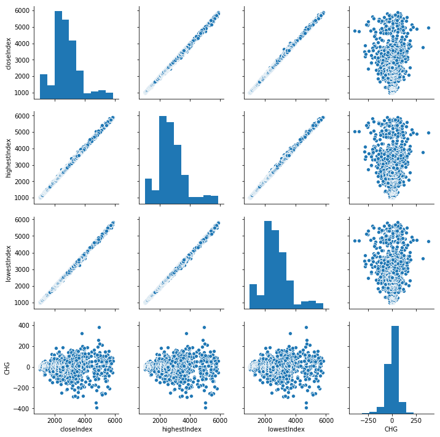

```python
%matplotlib inline
import seaborn as sns
sns.pairplot(df)
# 收盘指数当日最高指数和当日最低指数有着很强的线性正相关关系，存在严重的多重共线性，但他们与指数的涨跌相关性很弱
```

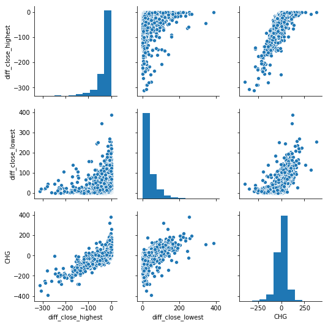

```python
# 考虑添加列，猜测涨跌与收盘价与单日最高价和最低价有相关性
df['diff_close_highest'] = df['closeIndex'] - df['highestIndex']
df['diff_close_lowest'] = df['closeIndex'] - df['lowestIndex']
df = df[['tradeDate','diff_close_highest','diff_close_lowest','CHG']]
sns.pairplot(df);
```

```python
df.head()
```

|  | tradeDate | diff_close_highest | diff_close_lowest | CHG |
| --- | --- | --- | --- | --- |
| 0 | 2006/3/1 | -1.07 | 6.98 | 3.61 |
| 1 | 2006/3/2 | -17.38 | 3.99 | -17.95 |
| 2 | 2006/3/3 | -1.74 | 12.12 | 3.01 |
| 3 | 2006/3/6 | -5.55 | 2.76 | -2.81 |
| 4 | 2006/3/7 | -23.01 | 1.83 | -23.90 |

```python
# 貌似CHG与diff_close_highest和diff_close_lowest有线性相关性
# VIF值在10以下可以使用
from patsy import dmatrices
import statsmodels.api as sm
from statsmodels.stats.outliers_influence import variance_inflation_factor

y,X = dmatrices('CHG ~ diff_close_highest + diff_close_lowest', df, return_type = 'dataframe')
vif = pd.DataFrame()
vif['VIF Factor'] = [variance_inflation_factor(X.values, i) for i in range(X.shape[1])]
vif['features'] = X.columns
vif
```

|  | VIF Factor | features |
| --- | --- | --- |
| 0 | 2.672343 | Intercept |
| 1 | 1.040765 | diff_close_highest |
| 2 | 1.040765 | diff_close_lowest |

### 3.算法和技术

由于使用多个解释变量预测反应变量，反应变量是连续的，使用多元线性回归。

Ⅱ.分析部分对数据进行清洗，可视化探索，根据要解决的问题选择解释变量，选择合适的算法

## Ⅲ. 实现

```python
# 使用多远线性回归拟合数据
from sklearn.linear_model import LinearRegression
X = df[['diff_close_highest','diff_close_lowest']]
y = df['CHG']
X_train,X_test,y_train,y_test = X[:int(len(X)*0.8)],X[int(len(X)*0.8):],y[:int(len(y)*0.8)],y[int(len(y)*0.8):]
lm = LinearRegression()
lm.fit(X_train,y_train)
```

```
LinearRegression(copy_X=True, fit_intercept=True, n_jobs=None,
         normalize=False)
```

Ⅲ. 实现算法的实现步骤

## IV. 结果

```python
# R-squared分数
lm.score(X_test,y_test)
```

```
0.6840222647216501
```

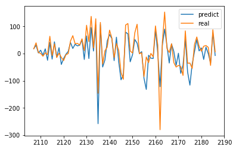

```python
# 可视化验证模型好坏
data = pd.DataFrame({'predict':lm.predict(X_test)[-80:],'real':y_test[-80:]})
data.plot();
```

IV. 结果模型的评估和验证

## V. 项目结论

模型在预测涨跌指标CHG有较好的表现

V. 项目结论项目的总结